# Classification

## Decision Tree

Let’s move on to decision tree. A Decision Tree is another supervised Machine learning algorithm. The decision tree is like a tree with nodes. The branches depend on a number of factors. It splits data into branches like these till it achieves a threshold value. A decision tree consists of the root nodes, children nodes, and leaf nodes.

The simplistic way of understanding decision tree would be a flow chart like this:

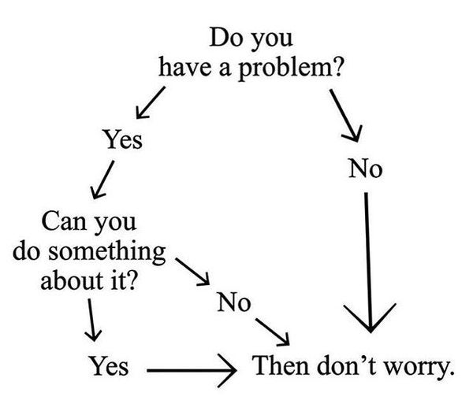

This is a simple decision tree with a lot of branches but only one possible classification outcome – *don’t worry*.

Here is another simple decision tree example:

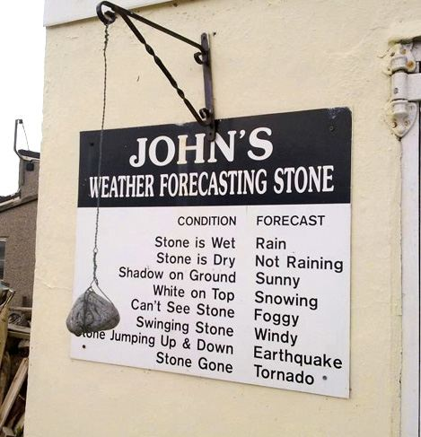

Decision trees learn from data to approximate the training data with a set of if-then-else decision rules. The deeper the tree, the more complex the decision rules and the fitter the model.

Decision tree has various algorithms to implement. In this tutorial, we are going to use `party` package which provides an implementation of conditional inference trees which embed tree-structured regression models into a well defined theory of conditional inference procedures.

Learn more about decision tree:

- [StatsQuest: Decision Trees](https://youtu.be/7VeUPuFGJHk)
- [Normalized Nerd: Decision Tree Classification Clearly Explained!](https://youtu.be/ZVR2Way4nwQ)

Ok, let’s get it started! First you will need to load the `party` package. Then building the tree model with `ctree()`. This function is actually pretty straight-forward and very similar to what we have been using in the `lm()` or `glm()`. Basically, you state the predictor and predicted variables clearly.

```r
library(party)
# Create the tree model
moocTree <- ctree(
  certified_yes ~ forum.posts + grade + assignment,
  data = moocD)
```

Let’s take a look at the result:

```r
print(moocTree)
```

```
##
##   Conditional inference tree with 4 terminal nodes
##
## Response:  certified_yes
## Inputs:  forum.posts, grade, assignment
## Number of observations:  1000
##
## 1) assignment <= 12; criterion = 1, statistic = 689.719
##   2)*  weights = 254
## 1) assignment > 12
##   3) grade <= 7; criterion = 1, statistic = 244.485
##     4)*  weights = 16
##   3) grade > 7
##     5) forum.posts <= 80; criterion = 1, statistic = 39.938
##       6)*  weights = 13
##     5) forum.posts > 80
##       7)*  weights = 717
```

These rules may not be very easy to understand, so let’s take a look at a graphical representation.

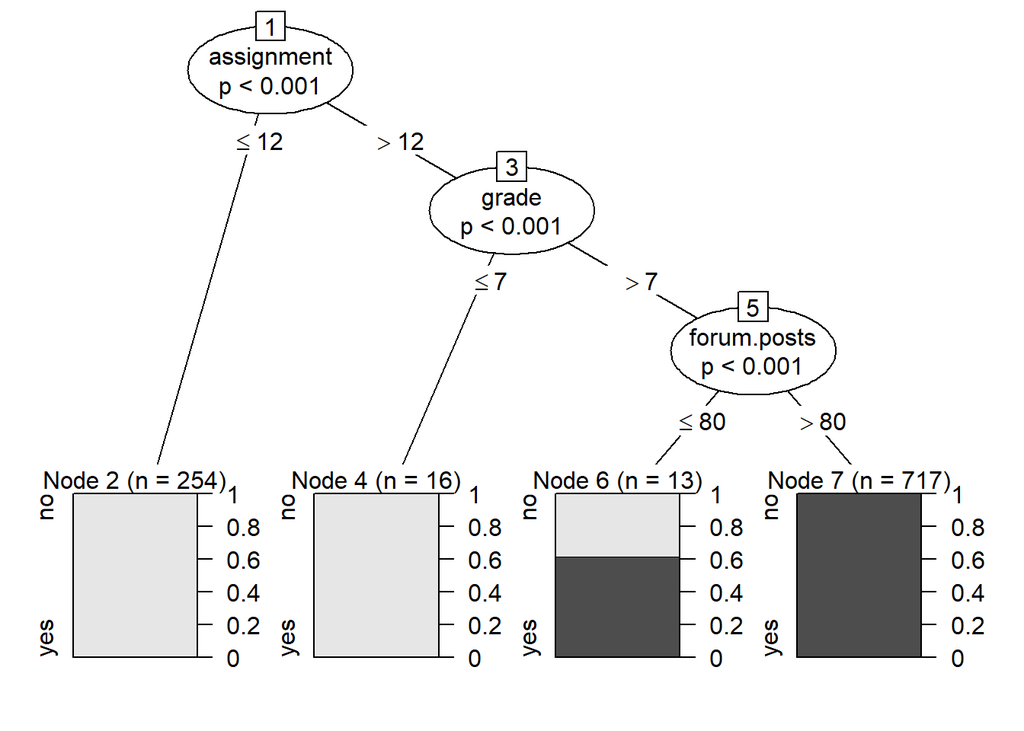

```r
plot(moocTree)
```

To understand what the decision tree is saying, we want to start with the root of the tree (the first decision node). Looking at the first decision node, we know that the variable that the decision is determined by is `assignment`. There are two leaves from this node: first if the `assignment` is less than or equal to 12 then it drops down into the group of no (*n* = 254).

## Naive Bayes

Naive Bayes models are a group of extremely fast and simple classification algorithms that are often suitable for very high-dimensional datasets. Because they are so fast and have so few tunable parameters, they end up being very useful as a quick-and-dirty baseline for a classification problem.

Naive Bayes classifiers are built on Bayesian classification methods. These rely on Bayes’s theorem, which is an equation describing the relationship of conditional probabilities of statistical quantities. In Bayesian classification, we’re interested in finding the probability of a label given some observed features, which we can write as $P(L | features)$. Bayes’s theorem tells us how to express this in terms of quantities we can compute more directly:

$$P(L | features) = \frac{P(features | L)P(L)}{P(features)}$$

If we are trying to decide between two labels—let’s call them L1 and L2—then one way to make this decision is to compute the ratio of the posterior probabilities for each label:

$$\frac{P(L_1 | features)}{P(L_2 | features)} = \frac{P(features | L_1)P(L_1)}{P(features | L_2)P(L_2)}$$

All we need now is some model by which we can compute $P(features | L_i)$ for each label. Such a model is called a generative model because it specifies the hypothetical random process that generates the data. Specifying this generative model for each label is the main piece of the training of such a Bayesian classifier. The general version of such a training step is a very difficult task, but we can make it simpler through the use of some simplifying assumptions about the form of this model.

This is where the “naive” in “naive Bayes” comes in: if we make very naive assumptions about the generative model for each label, we can find a rough approximation of the generative model for each class, and then proceed with the Bayesian classification.

More about Naive Bayes:

- [StatQuest: Naive Bayes, Clearly Explained!!!](https://youtu.be/O2L2Uv9pdDA)
- [Luis Serrano: Naive Bayes classifier: A friendly approach](https://youtu.be/Q8l0Vip5YUw)

Alright, let’s get it started. To get Naive Bayes started in R, you’ll need to install the `e1071` package.

The implementation is actually super straight forward. Just like everything we have seen.

```r
library(e1071)
moocNB <- naiveBayes(
  certified_yes ~ forum.posts + grade + assignment,
  data = moocD)
```

Let’s take a look how well our model perform by obtaining a predicted y variable certified_pred and compare that with the certified. Here we are using `predict()` to use given Xs to predict the given y.

```r
certified_pred_NB <- predict(moocNB, moocD[,2:4]) ## Here we are using [] to index the columns except from the certified_yes
```

And then let’s compare it with the actual labels we get in moocD. Here we are using `==` to compare whether each element in `certified_pred_NB` matches the elements in certified. The result returns a list of `TRUE` or `FALSE`. We can take the summation of them and divided them by the length of this list to obtain the accuracy because `TRUE` is viewed as 1 while `FALSE` is viewed as 0.

```r
performance = moocD$certified_yes == certified_pred_NB
cat('The accuracy is', sum(performance)/length(performance)*100, '%') ## Here we are using cat to put everything together.
```

```
## The accuracy is 99.8 %
```

Wait, what? Our accuracy is 99.8%. Is that too good to be true. Well… you shouldn’t be surprised because of two reasons: (a) The data is very pretty as shown in the descriptives. This classification task is almost like a no-brainer. (b) We are using the Xs that we used to train the model to obtain the predicted value. So basically, the model has already seen them. That’s cheating! How about we separate a group of data that the model has never seen and play a fair game?